# Between-Sample (Beta) Diversity of microbes in dairy samples

Kailyn Hanke

2025-04-19

In this document I evaluated sequencing depth and normalized the read counts between samples. I then calculated community dissimilarities and ran statistics with PERMANOVA and betadispR before visualizing the community data with ordinations (PCoA and NMDS plots).

# Goals

1. Load in phyloseq data with rooted tree & colors and functions.
2. Evaluate sequencing depth and remove samples, if needed.
3. Normalize the read counts between samples.
4. Calculate community **dis**similarities. Numbers between 0 and 1. If 0, completely similar versus if they are 1, then they’re completely dissimilar.
   1. **Sorensen**: Shared Species as a binary value: Abundance-unweighted
   2. **Bray-Curtis**: Shared Abundant species: Abundance-weighted
   3. **(Abundance-)Weighted UNIFRAC**: Consider Abundant Species and where they fall on the tree
5. Run statistics with functions from the vegan R package:
   1. PERMANOVA with `adonis2()`.
   2. betadispR with `betadisper()` and `permutest()`.
6. Visualize the community data with two unconstrained Ordinations:
   1. **PCoA**: Linear Method. Eigenvalue = how much variation is explained by each axis. Choose to view axis 1, 2, 3, etc. and plot them together.
   2. **NMDS**: Non-linear. Smush multiple Dimensions into 2 or 3 axes. Need to report Stress value (ideally <0.15).
1. We will need the `phytree_preprocessed_physeq.RData`, which includes a rooted tree (ideally within the archaea!) that we created in `analysis/04B_Phylogenetic_Tree_Inspection.Rmd`.

## Outputs

1. Calculated beta-diversity dissimilarity measures (*e.g.* Sorensen, Bray-Curtis, abundance-unweighted and -weighted UniFrac) across every sample.
2. Ordination figures (*i.e.,* PCoA/NMDS) to include in the scientific paper that visualize the data as it relates to the scientific question.
3. Statistical tests (*i.e.,* PERMANOVA & betadisper) conveying the measured and quantified changes and patterns in biodiversity.

# Scientific Question

INTERPRETATION #1: What is your scientific question and hypotheses? Do they relate to abundance? Presence/absence? Phylogeny?

Primary Scientific Question: How does the microbial diversity of dairy samples change throughout the skim milk powder manufacturing process?

- *Null Hypothesis:* Microbial biodiversity (*e.g.* Sorensen and Bray Curtis) does not vary as the milk is processed (as it goes from farm bulk tank milk to its final form of skim milk powder).
- *Alternative Hypothesis #1:* Microbial composition (*e.g.* Sorensen) will become more dissimilar as the dairy samples move further along the supply chain. There is an inverse relationship between richness and how processed the dairy samples are.

Note: I came up with alternative hypothesis #2 because I could see there being bif differences in the presence/absence of certain bacteria on either end of the processing pipeline due to the various steps and conditions that are involved in the manufacturing process. I thought that we would probably lose a lot of specific types of bacteria that might not be able to handle heat (pasteurization) or dry environments like within Skim Milk Powder samples.

- *Alternative #2 Hypothesis*: Dominant members of the microbial community (*e.g.* Bray-Curtis) are unique in Skimmed Milk Powder samples (most processed) compared to Bulk Tank Milk samples (least) processed).

Note: I came up with alternative hypothesis #2 because I thought that certain processes in the pipeline like pasteurization may eliminate a large number of bacteria, and enrich for specific bacteria, majorly shifting the dominant bacteria in these samples.

I would like my null hypothesis and alternative hypothesis #1 to relate to presence absence, while I would like my alternative hypothesis #2 to relate more to abundance (focusing on dominant species).

# Set up

## Timing of this script

```r
# What time did we start running this script?
start_time <- Sys.time()
```

## Set the seed

```r
set.seed(111111)
```

## Load Packages, colors & functions

```r
pacman::p_load(tidyverse, devtools, phyloseq, patchwork, vegan,
               install = FALSE)

# Load Colors
source("code/colors.R")

# Load functions
source("code/functions.R")
```

# 1. Load in the data

Kept in the code below used to troubleshoot loading in data in case it happens again and I need something to refer back to!

```r
# load phyloseq object

load("data/04_PhylogeneticTree/midpoint_rooted_physeq_cut.RData")
midpoint_rooted_physeq_cut
```

```
## phyloseq-class experiment-level object
## otu_table()   OTU Table:         [ 71237 taxa and 192 samples ]
## sample_data() Sample Data:       [ 192 samples by 55 sample variables ]
## tax_table()   Taxonomy Table:    [ 71237 taxa by 9 taxonomic ranks ]
## phy_tree()    Phylogenetic Tree: [ 71237 tips and 71236 internal nodes ]
```

```r
#this didn't work when knitting for some reason

#try loading absolute path
#load("/local/workdir/kah357/Amplicon_Project/data/04_PhylogeneticTree/midpoint_rooted_physeq_cut.RData")

#check to see if the file exists
#file.exists("/local/workdir/kah357/Amplicon_Project/data/04_PhylogeneticTree/midpoint_rooted_physeq_cut.RData")

#TRUE! It exists!!

# Advice of CHatGPT: explicitly assign again (redundant but safe for knitting)
#midpoint_rooted_physeq_cut <- get("midpoint_rooted_physeq_cut")

#also did not work!
#load dataframe
metadata_df_cut <- read.csv("data/05_Biodiversity/metadata_df_cut.csv", row.names = 1)



# Intuition check on seq depth
min(sample_sums(midpoint_rooted_physeq_cut))
```

```
## [1] 4428
```

```r
#Check Range and median
range(sample_sums(midpoint_rooted_physeq_cut)) #min:4428 #max:170404
```

```
## [1]   4428 170404
```

```r
median(sample_sums(midpoint_rooted_physeq_cut)) #median: 60989
```

```
## [1] 60989
```

```r
# Create a data frame of sample names and their sequence depths
sample_depths_df <- data.frame(
  Sample = sample_names(midpoint_rooted_physeq_cut),
  Depth = sample_sums(midpoint_rooted_physeq_cut)
)

# Sort by depth from lowest to highest
sample_depths_sorted <- sample_depths_df[order(sample_depths_df$Depth), ]

# View the 50 samples with the lowest sequence depth
head(sample_depths_sorted, 50)
```

```
##                Sample Depth
## ERR3141454 ERR3141454  4428
## ERR3141501 ERR3141501  9143
## ERR3141434 ERR3141434  9920
## ERR3141489 ERR3141489 17924
## ERR3141496 ERR3141496 18811
## ERR3141543 ERR3141543 18944
## ERR3141539 ERR3141539 19423
## ERR3141520 ERR3141520 20090
## ERR3141488 ERR3141488 21006
## ERR3141503 ERR3141503 21026
## ERR3141433 ERR3141433 21204
## ERR3141546 ERR3141546 21282
## ERR3141535 ERR3141535 23166
## ERR3141402 ERR3141402 24490
## ERR3141415 ERR3141415 25301
## ERR3141527 ERR3141527 25605
## ERR3141538 ERR3141538 25829
## ERR3141435 ERR3141435 25871
## ERR3141432 ERR3141432 26489
## ERR3141551 ERR3141551 28440
## ERR3141560 ERR3141560 28722
## ERR3141413 ERR3141413 29499
## ERR3141427 ERR3141427 30923
## ERR3141404 ERR3141404 31172
## ERR3141537 ERR3141537 31577
## ERR3141400 ERR3141400 32454
## ERR3141540 ERR3141540 32714
## ERR3141536 ERR3141536 33937
## ERR3141512 ERR3141512 34832
## ERR3141556 ERR3141556 34918
## ERR3141554 ERR3141554 35084
## ERR3141500 ERR3141500 35149
## ERR3141494 ERR3141494 35178
## ERR3141542 ERR3141542 35740
## ERR3141552 ERR3141552 35841
## ERR3141522 ERR3141522 36096
## ERR3141547 ERR3141547 36120
## ERR3141483 ERR3141483 36160
## ERR3141490 ERR3141490 37263
## ERR3141416 ERR3141416 37508
## ERR3141397 ERR3141397 37769
## ERR3141545 ERR3141545 37784
## ERR3141420 ERR3141420 38986
## ERR3141403 ERR3141403 39168
## ERR3141548 ERR3141548 39250
## ERR3141532 ERR3141532 39477
## ERR3141530 ERR3141530 39775
## ERR3141442 ERR3141442 39983
## ERR3141408 ERR3141408 40974
## ERR3141437 ERR3141437 41782
```

```r
#Bottom 5
#Sample Depth
#ERR3141454 ERR3141454  4428
#ERR3141501 ERR3141501  9143
#ERR3141434 ERR3141434  9920
#ERR3141489 ERR3141489 17924
#ERR3141496 ERR3141496 18811

#This addressed in the next part of this document^... I struggled to decide what my sample depth cutoff should be.
```

# Normalizing the Read Depth

## 2. Explore the Raw Read Counts

```r
# calculate read counts per sample
raw_TotalSeqs_df <-
  midpoint_rooted_physeq_cut %>%
  # Calculate the total number of sequences/reads
  sample_sums() %>%
  data.frame()

# Take a look
head(raw_TotalSeqs_df)
```

```
##                 .
## ERR3141386  60940
## ERR3141387  46996
## ERR3141388 170404
## ERR3141389 109440
## ERR3141390  52079
## ERR3141391  63605
```

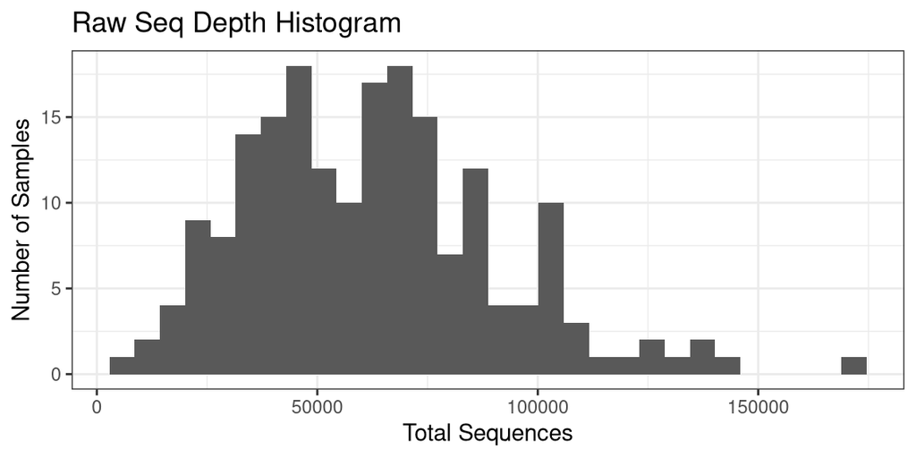

```r
#Ask: not F and R

# Rename the column
colnames(raw_TotalSeqs_df)[1] <- "TotalSeqs"

# add a new column of num_ASVs (RAW, non-noramlized # ASVs)
raw_TotalSeqsASVs_df <-
  raw_TotalSeqs_df %>%
  mutate(num_ASVs = colSums(otu_table(midpoint_rooted_physeq_cut) > 1))

#View(raw_TotalSeqsASVs_df)

# Plot histogram of seq depth
# Plot full histogram of sequencing depth with no bin or axis limits
rawSeq_histogram <-
  raw_TotalSeqsASVs_df %>%
  ggplot(aes(x = TotalSeqs)) +
  geom_histogram() +  # let ggplot decide bins automatically
  labs(title = "Raw Seq Depth Histogram",
       x = "Total Sequences",
       y = "Number of Samples") +
  theme_bw()

# Print the plot
rawSeq_histogram
```

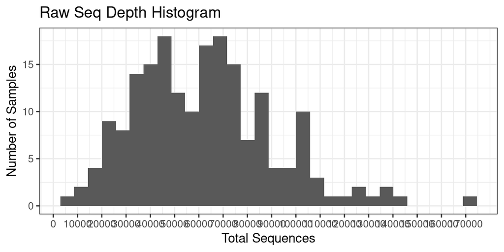

```r
#Add in more labels on x-axis

rawSeq_histogram_labels <-
  raw_TotalSeqsASVs_df %>%
  ggplot(aes(x = TotalSeqs)) +
  geom_histogram() +  # let ggplot decide bins automatically
  labs(title = "Raw Seq Depth Histogram",
       x = "Total Sequences",
       y = "Number of Samples") +
  scale_x_continuous(breaks = seq(0, max(raw_TotalSeqsASVs_df$TotalSeqs), by = 10000)) +
  theme_bw()

#print it
rawSeq_histogram_labels
```

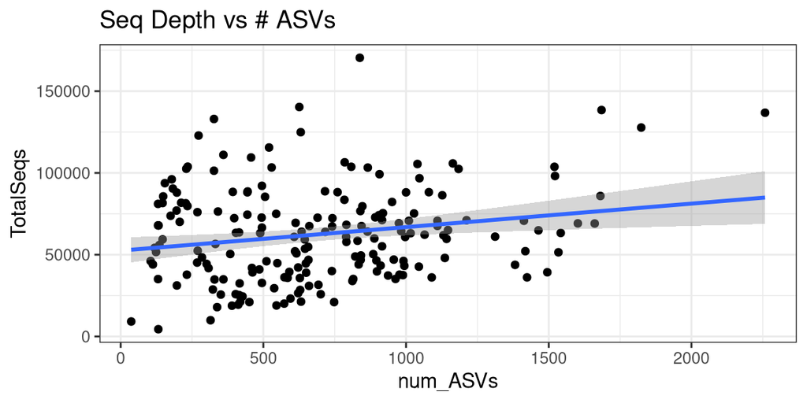

```r
# Plot Seq Depth versus num_ASVs
rawSeq_vs_numASV_plot <-
  raw_TotalSeqsASVs_df %>%
  ggplot(aes(x = num_ASVs, y = TotalSeqs)) +
  geom_point() +
  scale_y_continuous() +
  geom_smooth(method = "lm") +
  labs(title = "Seq Depth vs # ASVs") +
  theme_bw()

# Print the plot
rawSeq_vs_numASV_plot
```

```r
# is it significant?
summary(lm(TotalSeqs ~ num_ASVs, data = raw_TotalSeqsASVs_df))
```

```
##
## Call:
## lm(formula = TotalSeqs ~ num_ASVs, data = raw_TotalSeqsASVs_df)
##
## Residuals:
##    Min     1Q Median     3Q    Max
## -49965 -22277  -3946  18829 105867
##
## Coefficients:
##              Estimate Std. Error t value Pr(>|t|)
## (Intercept) 52496.668   4061.192  12.926  < 2e-16 ***
## num_ASVs       14.368      5.055   2.842  0.00497 **
## ---
## Signif. codes:  0 '***' 0.001 '**' 0.01 '*' 0.05 '.' 0.1 ' ' 1
##
## Residual standard error: 28320 on 190 degrees of freedom
## Multiple R-squared:  0.04078,    Adjusted R-squared:  0.03573
## F-statistic: 8.078 on 1 and 190 DF,  p-value: 0.00497
```

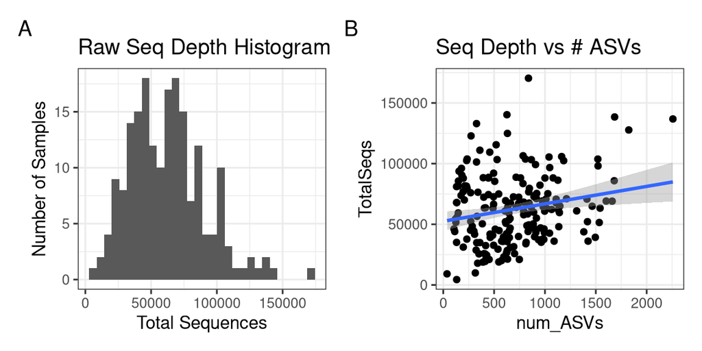

```r
# Put the two plots together.
rawSeq_histogram + rawSeq_vs_numASV_plot +
  plot_annotation(tag_levels = "A")
```

INTERPRETATION #2: Evaluating the above plots, what did you scale the read counts to in your dataset? Why did you choose that number? Do you think it is sufficient to perform a beta-diversity analysis and accurately compare your data to one another?

When looking at the above plots, I scaled ny read counts to 4428 in my dataset. I landed on this number based on following the class dataset in my earlier processing steps. I got rid of outliers, and samples with low sequencing depth relative to the rest of my samples. Note that in the class dataset, they discarded any samples with sequencing depth less than ~1500, since my dataset is much more deeply sequenced, I upped this value to ~4500. It also looked like the rarefaction curves plateaued in all my samples when I did a visual analysis.

I do not think this is a sufficient number to perform a beta-diversity analysis and accurately compare my data to one another, as I have a very large range in sequencing depth for my data: min = 4428, max = 170 404. The linear model suggests a statistically significant positive relationship between total sequencing depth and ASV richness, with a p-value of 0.00497 for the slope. But the R-squared value is pretty low (0.04).

Based on what I see in my histogram, in the following step I am going to remove samples with sequencing depth less than 20 000. I think this would be a better number to get accurate results when comparing my data to one another.

###Removing low sequence depth samples

```r
# Subset samples based on sequencing depth
midpoint_rooted_physeq_cut20000 <- subset_samples(midpoint_rooted_physeq_cut, sample_sums(midpoint_rooted_physeq_cut) >= 20000)

# Prune taxa that are now zero across all samples
midpoint_rooted_physeq_cut20000 <- prune_taxa(taxa_sums(midpoint_rooted_physeq_cut20000) > 0, midpoint_rooted_physeq_cut20000)

# Check how many samples remain
midpoint_rooted_physeq_cut20000 #185 samples, successfully removed!
```

```
## phyloseq-class experiment-level object
## otu_table()   OTU Table:         [ 70392 taxa and 185 samples ]
## sample_data() Sample Data:       [ 185 samples by 55 sample variables ]
## tax_table()   Taxonomy Table:    [ 70392 taxa by 9 taxonomic ranks ]
## phy_tree()    Phylogenetic Tree: [ 70392 tips and 70391 internal nodes ]
```

```r
# Create updated metadata dataframe
metadata_df_cut20000 <-
  midpoint_rooted_physeq_cut20000 %>%
  sample_data() %>%
  data.frame()

save(midpoint_rooted_physeq_cut20000,
     file = "data/06_Ordination/midpoint_rooted_physeq_cut20000.RData")

save(metadata_df_cut20000,
     file = "data/06_Ordination/metadata_df_cut20000.RData")
```

# 3. Scale Read Counts

```r
min(sample_sums(midpoint_rooted_physeq_cut20000)) # 20090
```

```
## [1] 20090
```

```r
# Scale the reads
scaled_physeq <-
  midpoint_rooted_physeq_cut20000 %>%
  scale_reads(round = "matround")

# Look at it
scaled_physeq
```

```
## phyloseq-class experiment-level object
## otu_table()   OTU Table:         [ 64953 taxa and 185 samples ]
## sample_data() Sample Data:       [ 185 samples by 55 sample variables ]
## tax_table()   Taxonomy Table:    [ 64953 taxa by 9 taxonomic ranks ]
## phy_tree()    Phylogenetic Tree: [ 64953 tips and 64952 internal nodes ]
```

```r
# Save it in 06_Ordination
save(scaled_physeq,
     file = "data/06_Ordination/scaled_physeq.RData")


# Make a metadata dataframe
metadata_df_cut20000 <-
  midpoint_rooted_physeq_cut20000 %>%
  sample_data() %>%
  data.frame()


#Save it in data file
write.csv(metadata_df_cut20000, "data/06_Ordination/metadata_df_cut20000.csv", row.names = TRUE)


# Look at it more!
#View(data.frame(otu_table(midpoint_rooted_physeq_cut)))
#View(data.frame(otu_table(scaled_physeq)))

# Confirm seq read depth of scaled_physeq
scaled_TotalSeqs_df <-
  scaled_physeq %>%
  sample_sums() %>%
  data.frame()

colnames(scaled_TotalSeqs_df)[1] <- "TotalSeqs"

# add a new column of num_ASVs (RAW, non-noramlized # ASVs)
scaled_TotalSeqsASVs_df <-
  scaled_TotalSeqs_df %>%
  mutate(num_ASVs = colSums(otu_table(scaled_physeq) > 1))

# Plot it!
scaledSeq_histogram <-
  scaled_TotalSeqs_df %>%
  ggplot(aes(x = TotalSeqs)) +
  geom_histogram() +
  labs(title = "Scaled Seq Depth Histogram") +
  scale_x_continuous() +
  theme_bw()

# Scaling always gives us a range!
# Minimum sequences
min(scaled_TotalSeqs_df$TotalSeqs)
```

```
## [1] 19933
```

```r
# Total Range
range(scaled_TotalSeqs_df)
```

```
## [1] 19933 20271
```

```r
# How many is that range?
range_seqs <- (max(scaled_TotalSeqs_df$TotalSeqs) - min(scaled_TotalSeqs_df$TotalSeqs))
range_seqs
```

```
## [1] 338
```

```r
# And in terms of percent?
range_seqs/max(scaled_TotalSeqs_df$TotalSeqs)
```

```
## [1] 0.01667407
```

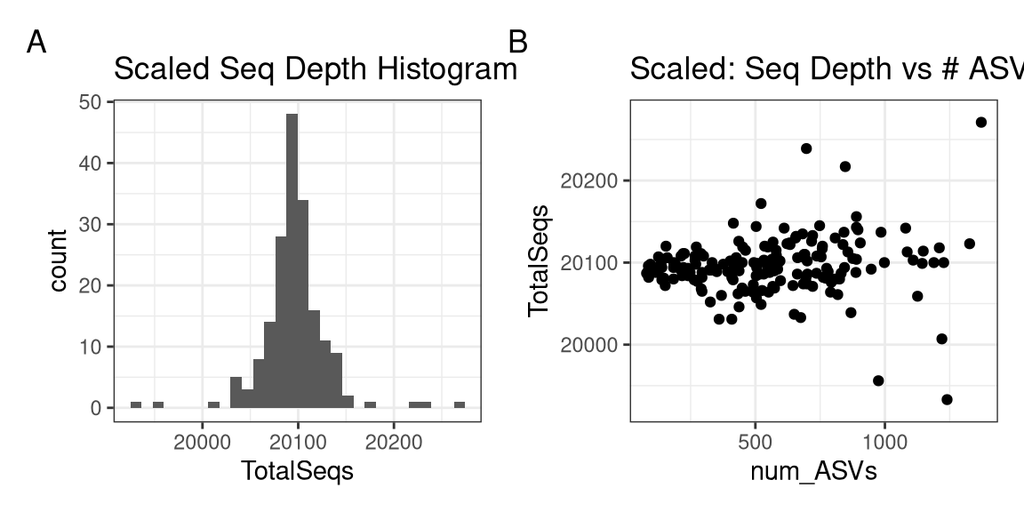

```r
#View(scaled_TotalSeqs_df)


# Set the axis min and max for the next plot
max_y <- max(scaled_TotalSeqs_df$TotalSeqs) + 10
min_y <- min(scaled_TotalSeqs_df$TotalSeqs) - 10

# Now, draw the plot
scaledSeq_vs_numASV_plot <-
  scaled_TotalSeqsASVs_df %>%
  ggplot(aes(x = num_ASVs, y = TotalSeqs)) +
  geom_point() +
  scale_y_continuous(limits = c(min_y, max_y)) +
  #geom_smooth(method = "lm") +
  theme_bw() +
  labs(title = "Scaled: Seq Depth vs # ASVs")

# Put the two plots together.
scaledSeq_histogram + scaledSeq_vs_numASV_plot +
  plot_annotation(tag_levels = "A")
```

INTERPRETATION #3: Evaluate the scaled read count plots above. Are the total number of sequences across all of your samples in the same general range? What is the minimum and maximum (i.e., the range) of the sequencing depth? How was the relationship with the number of ASVs modified after scaling the read counts?

# Beta Diversity: Dissimilarity Metrics in Microbial Ecology

# 4. Calculating dissimilarity

Now, let’s make distance objects of the dissimilarity measures we used in class!

```r
# Sorensen Dissimiliarty
scaled_sorensen_dist <- phyloseq::distance(scaled_physeq, method = "bray", binary = TRUE)

# What does it look like?
class(scaled_sorensen_dist)
```

```
## [1] "dist"
```

```r
str(scaled_sorensen_dist)
```

```
##  'dist' num [1:17020] 0.828 0.847 0.865 0.834 0.884 ...
##  - attr(*, "maxdist")= num 1
##  - attr(*, "Size")= int 185
##  - attr(*, "Labels")= chr [1:185] "ERR3141386" "ERR3141387" "ERR3141388" "ERR3141389" ...
##  - attr(*, "Diag")= logi FALSE
##  - attr(*, "Upper")= logi FALSE
##  - attr(*, "method")= chr "binary bray"
##  - attr(*, "call")= language vegdist(x = c(0, 182, 12, 0, 0, 0, 5539, 59, 512, 1458, 38, 0, 59, 84,  1176, 0, 0, 37, 0, 55, 57, 510, 139, 5647| __truncated__ ...
```

```r
#head(as.matrix(scaled_sorensen_dist))

# Bray-Curtis Dissimiliarty
scaled_bray_dist <- phyloseq::distance(scaled_physeq, method = "bray", binary = FALSE)

# Abundance-Unweighted UniFrac
scaled_uUnifrac_dist <- phyloseq::distance(scaled_physeq, method = "unifrac")

# Abundance-Weighted UniFrac
scaled_wUnifrac_dist <- phyloseq::distance(scaled_physeq, method = "wunifrac")
```

INTERPRETATION #4: Which dissimilarity metric is most related to your scientific question? Why or why not?

My broad scientific question is very general: How does the microbial diversity of dairy samples change throughout the skim milk powder manufacturing process?

Because of this, it could be related to any of the dissimilarity metrics we’ve discussed. But with the way I’ve framed my null hypothesis and alternative hypothesis #1, I want to first focus on looking how my samples differ in presence/absence of species. So I would like to focus my analysis first on using Sorensen (Sorensen over Jaccard because I want to give greater weight to shared species). In my initial analysis I really just want to focus on who’s there!! Then, I would like to incorporate abundance data and use Bray-Curtis when assessing alternative hypothesis #2!

# 5a. PERMANOVA: Testing Means/Centroids

Here, we will focus on comparing the Sorensen and the Bray-Curtis.

**PLEASE NOTE**: in this document I do not take season into account at all. Please see my series of three additional analysis documents where I do look at season as a variable. I am adding this note in after I initially completed this analysis and was very confused by the results I saw in my ordinations, specifically the distinct, separate clustering within Skim Milk Powder samples and Skim Milk Silo samples that I could not explain. I then went back and read my paper again and realized that season was probably a pretty important variable to consider in my analysis… #GutCheck!

### Sorensen

```r
# Sorensen
# Note I am not using multiple terms here, as I am only interested in looking at sample type. Later in my analysis I might look into early/late season samples, but that is an entirely separate research question!

sorensen_sample_result <- adonis2(scaled_sorensen_dist ~ environment_material,
                         data = metadata_df_cut20000,
                         by = "terms")

sorensen_sample_result
```

```
## Permutation test for adonis under reduced model
## Terms added sequentially (first to last)
## Permutation: free
## Number of permutations: 999
##
## adonis2(formula = scaled_sorensen_dist ~ environment_material, data = metadata_df_cut20000, by = "terms")
##                       Df SumOfSqs      R2      F Pr(>F)
## environment_material   5    6.948 0.09808 3.8931  0.001 ***
## Residual             179   63.890 0.90192
## Total                184   70.838 1.00000
## ---
## Signif. codes:  0 '***' 0.001 '**' 0.01 '*' 0.05 '.' 0.1 ' ' 1
```

```r
#note I did not run "margin" instead of "terms" like the class data did, as I am only looking at one "term" (aka variable, which in my case is sample type)!
```

### Bray Curtis

```r
braycurtis_sample_result <- adonis2(scaled_bray_dist ~ environment_material,
                         data = metadata_df_cut20000,
                         by = "terms")

braycurtis_sample_result
```

```
## Permutation test for adonis under reduced model
## Terms added sequentially (first to last)
## Permutation: free
## Number of permutations: 999
##
## adonis2(formula = scaled_bray_dist ~ environment_material, data = metadata_df_cut20000, by = "terms")
##                       Df SumOfSqs      R2      F Pr(>F)
## environment_material   5   10.570 0.15678 6.6565  0.001 ***
## Residual             179   56.846 0.84322
## Total                184   67.416 1.00000
## ---
## Signif. codes:  0 '***' 0.001 '**' 0.01 '*' 0.05 '.' 0.1 ' ' 1
```

INTERPRETATION #5: Using the above example to guide you, run the appropriate PERMANOVA for your scientific question and interpret the results. What biological conclusion can you draw from your PERMANOVA results?

Both Sorensen and Bray-Curtis distance matrices showed significant results (p = 0.001). Using Sorensen, 9.8% of the variation in microbial community composition can be explained by sample type and using Bray Curtis, 15.7% of the variation in community composition can be explained by sample type. The F-statistic tells us how strongly a variable separates groups, relative to residuals. The F statistics were 3.89 for Sorensen and 6.66 for Bray-Curtis.

From these results, I understood that there is significant differences in the microbial communities depending on how far along the milk is in its processing pipeline (it’s sample type). While these F-statistic results aren’t as high as the ones we saw in the class analysis, I still think that these values show that there are is more meaningful separation of the samples by sample in Bray-Curtis when abundance is considered, versus in Sorensen when you’re really only looking at presence-absence.

Since Bray-Curtis explained slightly more variation than Sorensen, I interpreted this to mean that not only are there different taxa present in the communities, as determined by using Sorensen, but that the relative abundances of these taxa further contribute to the differences we are seeing in microbial compositions between the sample groups.

# 5b. Betadisper: Testing Variances/Dispersions

Some background (from Mar’s analysis):

`betadisper()` is an important companion to PERMANOVA when analyzing beta diversity in microbial ecology. It checks a key assumption of PERMANOVA: homogeneity of group dispersions (variances). **If this assumption is violated, the PERMANOVA results might be driven by differences in spread rather than true differences in community composition.**

**In Summary:**

| Function | What it does | Significance test? | Output includes |
| --- | --- | --- | --- |
| `betadisper()` | Computes within-group distances to centroids (dispersion) | ❌ No | Distances, centroids, model object |
| `permutest()` | Tests if group dispersions differ using permutations | ✅ Yes | F-value, permutation-based p-value |

**Always run `betadisper()` and `permutest()` after PERMANOVA** to test whether the groups have similar within-group variation.

- If p > 0.05 (not significant), the PERMANOVA result is reliable.
- If p < 0.05 (significant), be cautious—group differences may be due to dispersion, not composition! However, not all is lost as we may expect this to be biologically true.

## Sorensen

```r
# Homogeneity of Disperson test with beta dispr
# Sorensen Betadisper - Sample Type
dispr_sorensen_sample_type <- betadisper(scaled_sorensen_dist, metadata_df_cut20000$environment_material)
# permutest() performs a non-parametric permutation test, which is robust and valid for the kind of data used in beta diversity analysis (e.g., dissimilarity matrices).
permutest(dispr_sorensen_sample_type)
```

```
##
## Permutation test for homogeneity of multivariate dispersions
## Permutation: free
## Number of permutations: 999
##
## Response: Distances
##            Df  Sum Sq  Mean Sq      F N.Perm Pr(>F)
## Groups      5 0.83216 0.166433 120.88    999  0.001 ***
## Residuals 179 0.24645 0.001377
## ---
## Signif. codes:  0 '***' 0.001 '**' 0.01 '*' 0.05 '.' 0.1 ' ' 1
```

## Bray Curtis

```r
# Bray-Curtis Betadisper - Sample Type
dispr_bray_sample_type <- betadisper(scaled_bray_dist, metadata_df_cut20000$environment_material)

permutest(dispr_bray_sample_type)
```

```
##
## Permutation test for homogeneity of multivariate dispersions
## Permutation: free
## Number of permutations: 999
##
## Response: Distances
##            Df Sum Sq Mean Sq      F N.Perm Pr(>F)
## Groups      5 1.5949 0.31898 17.176    999  0.001 ***
## Residuals 179 3.3243 0.01857
## ---
## Signif. codes:  0 '***' 0.001 '**' 0.01 '*' 0.05 '.' 0.1 ' ' 1
```

INTERPRETATION #6: Using the above example to guide you, run the appropriate betadisper() and permutest() for your scientific question and interpret the results. What biological conclusion can you draw from your dispersion analysis?

In my dispersion analysis, my Bray Curtis results are in agreement with the Sorensen results. Using both of these metrics, sample type has a significant betadisper()/permutest() result (p < 0.05). This means that group differences may be due to dispersion, not composition. This indicates that sample type likely has some biological difference in the variance, which means that we need to be careful in our PERMANOVA interpretations.

For example, sample types earlier in the processing pipeline, like bulk tank milk, could have higher dispersion due to having a wider range of microbial communities, while sample types later in the processing pipeline, like skimmed milk powder samples, could select for a few specific microbes and have lower dispersion. So it is possible these significant betadisper()/permutest() results could just be reflecting biological reality.

INTERPRETATION #7: Taking into account both the betadisper()/permutest() and the PERMANOVA (adonis2()) test that you ran, what biological conclusion can you draw regarding your data?

Since my PERMANOVA is significant and my betadisper()/permutest() is significant, it suggests that my groups differ in community composition (as determined by PERMANOVA) but ALSO that they may differ in dispersion (as determined by betadisper()/permutest()). This difference in dispersion can influence the PERMANOVA result; it introduces the possibility that the PERMANOVA significance is partly driven by the differences in group variability and not just compositional shifts between the groups.

Like we discussed in class, even with unequal dispersion, true ecological differences can still exist! Real biological processes like disturbance or environmental heterogeneity can cause both composition shifts and dispersion changes. I am now eager to use ordination plots to take a look!

# 6. Visualize Community Dissimilarity with Ordination

# 6a. PCoA: Principal Coordinates Analysis

```r
### SORENSEN
# First, calculate PCoA with Soresen
scaled_soren_pcoa <-
  ordinate(physeq = scaled_physeq,
         method = "PCoA",
         distance = "bray", binary = TRUE)

# Take a quick look
str(scaled_soren_pcoa)
```

```
## List of 5
##  $ correction: chr [1:2] "none" "1"
##  $ note      : chr "There were no negative eigenvalues. No correction was applied"
##  $ values    :'data.frame':  184 obs. of  5 variables:
##   ..$ Eigenvalues   : num [1:184] 6.54 2.5 1.74 1.29 1.02 ...
##   ..$ Relative_eig  : num [1:184] 0.0923 0.0353 0.0246 0.0183 0.0144 ...
##   ..$ Broken_stick  : num [1:184] 0.0315 0.0261 0.0233 0.0215 0.0202 ...
##   ..$ Cumul_eig     : num [1:184] 0.0923 0.1276 0.1522 0.1704 0.1848 ...
##   ..$ Cumul_br_stick: num [1:184] 0.0315 0.0576 0.0809 0.1024 0.1226 ...
##  $ vectors   : num [1:185, 1:184] -0.0906 -0.1316 0.0514 0.0626 -0.134 ...
##   ..- attr(*, "dimnames")=List of 2
##   .. ..$ : chr [1:185] "ERR3141386" "ERR3141387" "ERR3141388" "ERR3141389" ...
##   .. ..$ : chr [1:184] "Axis.1" "Axis.2" "Axis.3" "Axis.4" ...
##  $ trace     : num 70.8
##  - attr(*, "class")= chr "pcoa"
```

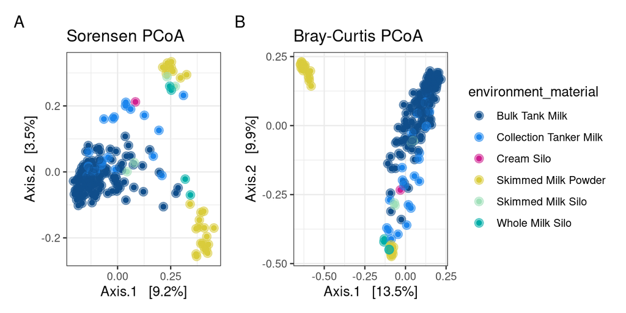

```r
# Plot it: Sorensen PCoA
sorensen_pcoa_plot <-
  plot_ordination(physeq = scaled_physeq,
                ordination = scaled_soren_pcoa,
                color = "environment_material",
                title = "Sorensen PCoA") +
  scale_color_manual(values = environment_colors) +
  geom_point(size = 3, alpha = 0.5, aes(color = environment_material)) +
  theme_bw() +
  theme(legend.position = "right")


### Bray-Curtis
# Second, calculate PCoA with Bray-Curtis
scaled_bray_pcoa <-
  ordinate(physeq = scaled_physeq,
         method = "PCoA",
         distance = "bray", binary = FALSE)

# Plot it: Bray-Curtis PCoA
bray_pcoa_plot <-
  plot_ordination(physeq = scaled_physeq,
                ordination = scaled_bray_pcoa,
                color = "environment_material",
                title = "Bray-Curtis PCoA") +
  scale_color_manual(values = environment_colors) +
  geom_point(size = 3, alpha = 0.5, aes(color = environment_material)) +
  theme_bw() +
  theme(legend.position = "right")

# Show the plots
sorensen_pcoa_plot + bray_pcoa_plot +
  plot_layout(guides = "collect") +
  plot_annotation(tag_levels = "A")
```

INTERPRETATION #8: Plot your data using a PCoA. Interpret what you can conclude from the PCoA.

In the Bray-Curtis PCoA more variation is explained (~13.5%) than Sorensen (~9.2%). Although this is a small difference (we gain ~4% variation explained), it suggests that abundance differences matter when comparing the compositional differences in these samples.

There were also a few key clustering features I wanted to mention. In the Sorensen PCoA we can see distinct clustering of the skimmed milk powder samples, skimmed milk silo samples and whole milk silo samples (into two separte clusters).

In the Bray Curtis PCoA, the clustering between sample type is a lot tighter. Here, you can see clear clustering of the skimmed milk powder samples into two groups, with one of the groups being completely isolated.

This is really interesting, but I am quite confused what could cause such distinct clustering patterns within the same sample type. I want to further explore what is driving this pattern we are seeing… is this primarily driven by have much fewer taxa, or by having distinct set of rare tax? I am going to go back to my paper and read about sample collection strategy.

It is also interesting that with the clustering in the Bray-Curtis PCoA plot you can sort of see a transition from bulk tank milk samples to collection tanker milk, to skimmed/whole milk silo samples to skimmed milk powder samples (albeit with major overlapping between the sample types) along axis 2. This was super cool to see, as this reflects the order of samples in the dairy processing pipeline.

Something that I do want to note about this, or that I have questions about, is that since the majority of this gradual sort of separation does not occur across axis 1 representing sample type, I do not know the metadata variable that explains this variation.

## 6b. NMDS: Non-Metric Multidimensional Scaling

```r
## SORENSEN
scaled_soren_nmds <-
  ordinate(physeq = scaled_physeq,
         method = "NMDS",
         distance = "bray", binary = TRUE)
```

```
## Square root transformation
## Wisconsin double standardization
## *** Best solution was not repeated -- monoMDS stopping criteria:
##      1: no. of iterations >= maxit
##     18: stress ratio > sratmax
##      1: scale factor of the gradient < sfgrmin
```

```r
# Plot it!
sorensen_nmds_plot <-
  plot_ordination(physeq = scaled_physeq,
                ordination = scaled_soren_nmds,
                color = "environment_material",
                title = "Sorensen NMDS") +
  scale_color_manual(values = environment_colors) +
  geom_point(size = 3, alpha = 0.5, aes(color = environment_material)) +
  theme_bw() +
  theme(legend.position = "right")

### Bray-Curtis
# Second, calculate NMDS with Bray-Curtis
scaled_bray_nmds <-
  ordinate(physeq = scaled_physeq,
         method = "NMDS",
         distance = "bray", binary = FALSE)
```

```
## Square root transformation
## Wisconsin double standardization
## *** Best solution was not repeated -- monoMDS stopping criteria:
##     18: stress ratio > sratmax
##      2: scale factor of the gradient < sfgrmin
```

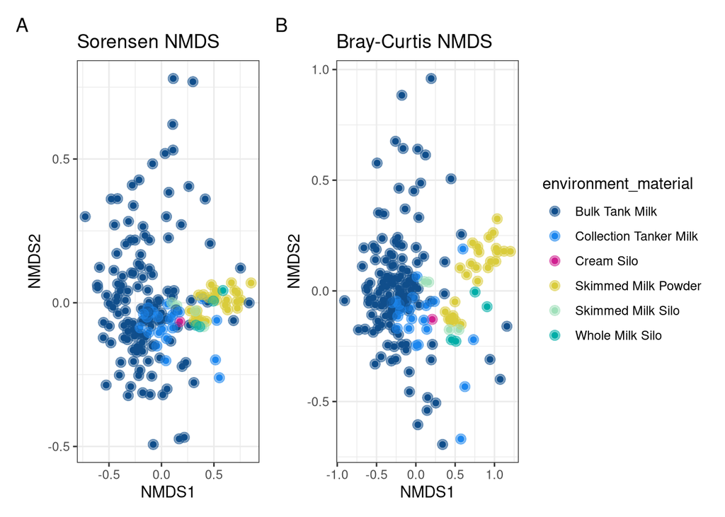

```r
# Plot it: Bray-Curtis NMDS
bray_nmds_plot <-
  plot_ordination(physeq = scaled_physeq,
                ordination = scaled_bray_nmds,
                color = "environment_material",
                title = "Bray-Curtis NMDS") +
  scale_color_manual(values = environment_colors) +
  geom_point(size = 3, alpha = 0.5, aes(color = environment_material)) +
  theme_bw() +
  theme(legend.position = "right")

# Show the plots
sorensen_nmds_plot + bray_nmds_plot +
  plot_layout(guides = "collect") +
  plot_annotation(tag_levels = "A")
```

INTERPRETATION #9: Plot your data using NMDS. Interpret what you can conclude from the NMDS.

The clustering in my Sorensen and Bray-Curtis NMDS plots were quite similar, although the clustering in the bulk tank samples was a bit tighter in my Bray-Curtis NMDS and the clustering of skimmed milk powder samples was tighter in Sorensen.

The centroid of the bulk tank milk and collection tanker milk looked like they almost overlapped in both plots, while there was a more distinct grouping of skimmed milk powder samples. It was also interesting to see that in the Sorensen NMDS plot all of the skim milk powder samples grouped together, while in the other ordination plots we can see two separate groups (although less distinct separation than we saw in the PCoA plots).

## All ordinations together!

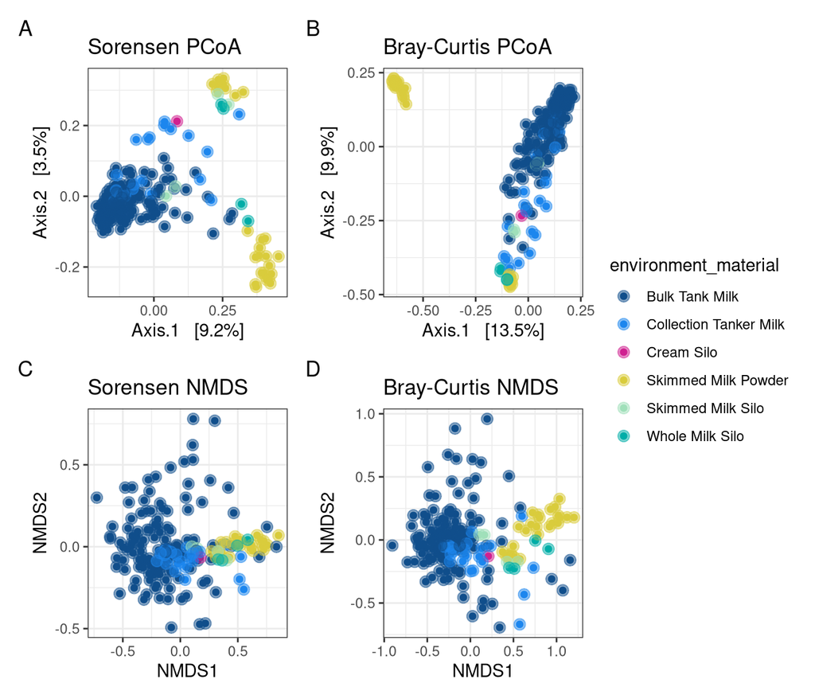

```r
sorensen_pcoa_plot + bray_pcoa_plot +
sorensen_nmds_plot + bray_nmds_plot +
  plot_layout(guides = "collect") +
  plot_annotation(tag_levels = "A")
```

INTERPRETATION #10: Plot both the PCoA and NMDS together. Which of the two visualizations work best for your data? Explain your reasoning.

In total transparency, I am a bit confused on the separate clustering within skim milk powder samples. This is an initial interpretation but I need to go revisit the paper.

I think that PCoA worked best for my data. In PCoA, particularly Bray-Curtis PCoA, compared to NMDS, there was more distinct clustering. I think it did a better job of showing how distinct/different the microbial composition of the skimmed milk powder samples were. With Bray-Curtis PCoA the gradual overlapping between the different samples directly reflected the amount of processing these dairy samples had been subjected to which was super cool.

# Now what?

Based on the results above, which metric would you use to write up your paper: Sorensen or Bray-Curtis?

Although in my initial questions/hypotheses I wanted to focus strictly on presence absence, if I had to pick only one metric to focus on when writing my paper I would select Bray-Curtis as I feel like I am able to tell a much clearer story, and visually there is the best separation between sample groups.

# Final info for Reproducibility

## Check Render Time

```r
# Take the time now that we are at the end of the script
end_time <- Sys.time()
end_time
```

```
## [1] "2025-05-01 22:37:43 EDT"
```

```r
# Echo the elapsed time
elapsed_time <- round((end_time - start_time), 3)
elapsed_time
```

```
## Time difference of 4.767 mins
```